# WUM_PD1

Adam Rydelek

06 - 03 - 2019

# 1 Wprowadzenie

W raporcie opiszę data set dotyczący transakcji wykonanych na allegro jednego dnia. Sprawdzę poprawność danych, podsumuję ich własności, oraz znajdę powiązania między nimi. Użyte przeze mnie pakiety to `stringi`, oraz `dplyr` do prostej obróbki danych, `DataExplorer`, `funModeling`, `minerva` do bardziej zaawansowanego opisu danych, oraz `RColorBrewer`, `ggplot2`, `corrplot`, `caret` do ich wizualizacji.

## 1.1 Wstępne podsumowanie danych:

```r
introduce(ds)
```

```
##    rows columns discrete_columns continuous_columns all_missing_columns
## 1 71628      14                5                  9                   0
##   total_missing_values complete_rows total_observations memory_usage
## 1                    0         71628            1002792      9721848
```

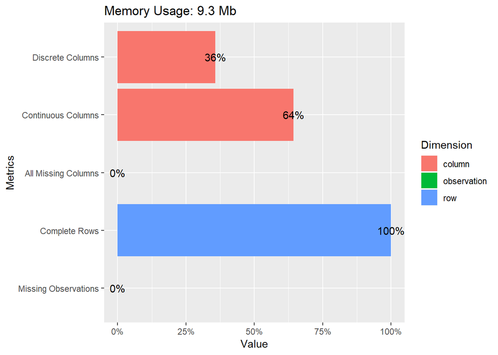

```r
plot_intro(ds)
```

# 2 Dokładne podsumowanie zmiennych

Aby zaobserwować, jak rozkładają się dane przedstawiłem tabelę zawierającą podsumowanie wszystkich zmiennych, za pomocą komendy `summary()`.

```r
summary(dsx[cols])
```

```
##      price           it_is_allegro_standard it_is_brand_zone
##  Min.   :     0.00   Min.   :0.0000         Min.   :0.00000
##  1st Qu.:     9.00   1st Qu.:0.0000         1st Qu.:0.00000
##  Median :    24.99   Median :1.0000         Median :0.00000
##  Mean   :    76.81   Mean   :0.5835         Mean   :0.01669
##  3rd Qu.:    68.45   3rd Qu.:1.0000         3rd Qu.:0.00000
##  Max.   :119000.00   Max.   :1.0000         Max.   :1.00000
##  it_seller_rating      date
##  Min.   :    -1   Min.   :2016-04-03 00:00:09
##  1st Qu.:  1581   1st Qu.:2016-04-03 12:50:14
##  Median :  6711   Median :2016-04-03 17:12:25
##  Mean   : 20403   Mean   :2016-04-03 16:24:21
##  3rd Qu.: 21007   3rd Qu.:2016-04-03 20:14:39
##  Max.   :292074   Max.   :2016-04-03 23:59:59
```

Aby lepiej zwizualizować powyższe informacje przedstawiłem histogramy zmiennych `price`, `date`, oraz `seller rating`.

## 2.1 Cena

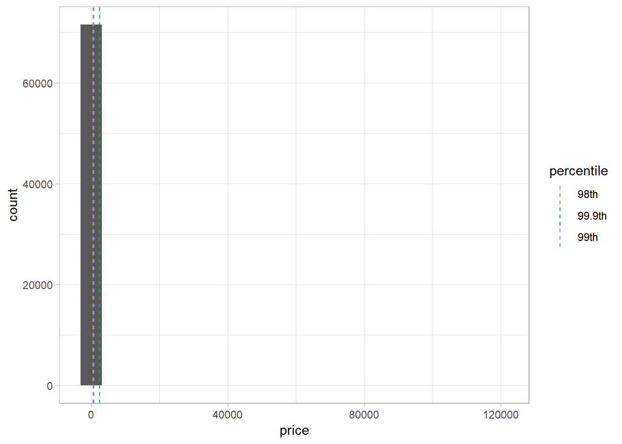

```r
percentile_var=quantile(ds$price, c(0.98, 0.99, 0.999), na.rm = T)
df_p=data.frame(value=percentile_var, percentile=c("98th", "99th", "99.9th"))
p1 <- ggplot(ds) +
  geom_histogram(bins=20, aes(price))+
  geom_vline(data=df_p, aes(xintercept=value,  colour = percentile), show.legend = TRUE, linetype="dashed") +
  theme_light()
p1
```

## 2.2 Data

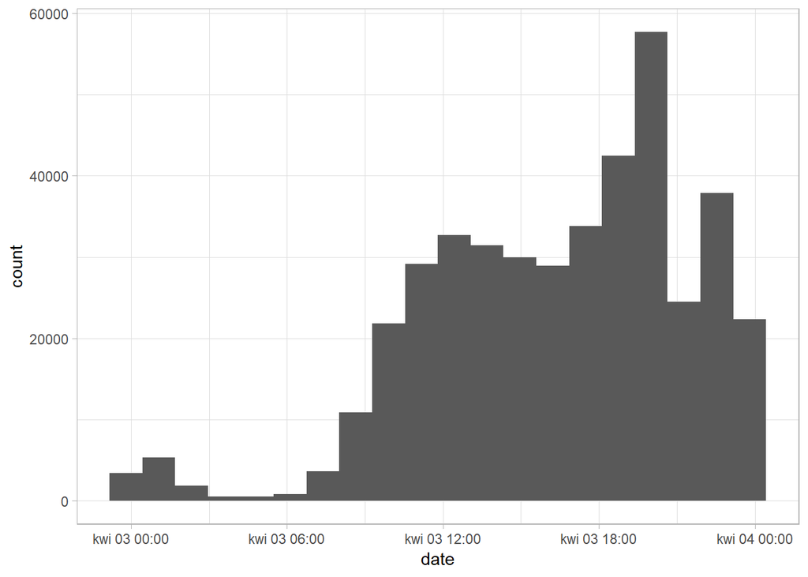

```r
p2 <- ggplot(dsx) +
  geom_histogram(bins=20, aes(date))+
  theme_light()
p2
```

## 2.3 Ocena sprzedającego

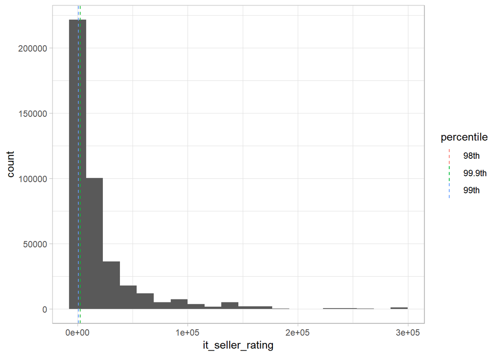

```r
p3 <- ggplot(dsx) +
  geom_histogram(bins=20, aes(it_seller_rating))+
  geom_vline(data=df_p, aes(xintercept=value,  colour = percentile), show.legend = TRUE, linetype="dashed") +
  theme_light()
p3
```

# 3 Wnioski z podsumowania i modyfikacja danych

## 3.1 Korekcja zmiennej “Price”

Z powyższego histogramu ceny ciężko zauważyć jakąkolwiek zależność, ponieważ tak wiele przedmiotów jest w cenie bliskiej zera. Moim rozwiązaniem tego problemu było usunięcie ze zbioru samochodów i motocykli/quadów, ponieważ były to przedmioty o najwyższej cenie, których było stosunkowo mało w stosunku do całej liczby rekordów, a dokładniej stanowiły 0.27% liczby wszystkich rekordów.

Po tej zmianie histogram wyglądał następująco:

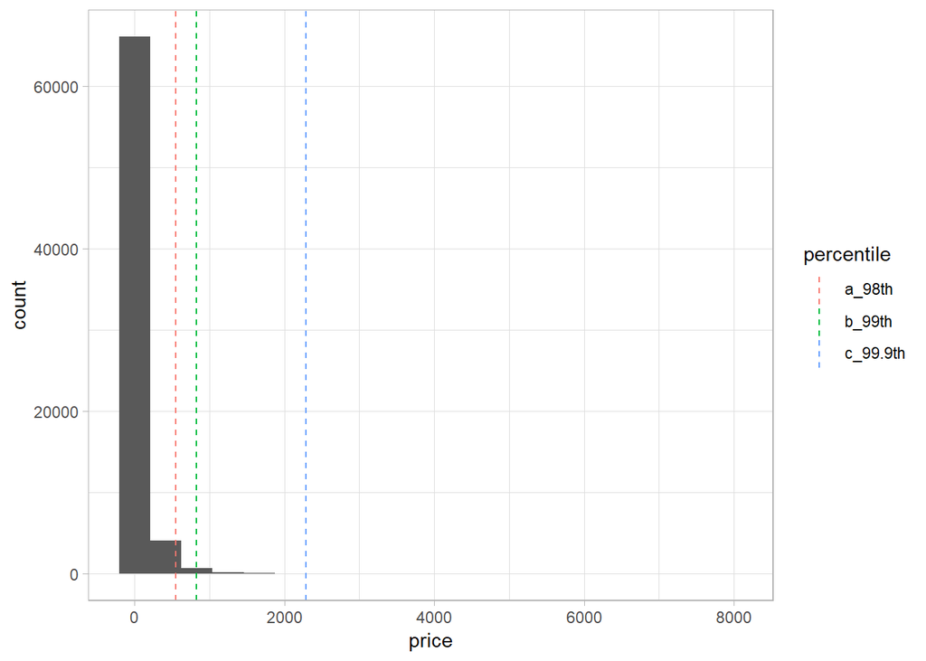

```r
dsnocars <- filter(ds, stri_detect(ds$categories, regex="(?=^((?!Samochody).)*$)(^((?!Motocykle).)*$)"))
dsnocars <- filter(dsnocars, price!=0)

percentile_var=quantile(dsnocars$price, c(0.98, 0.99, 0.999), na.rm = T)
df_p=data.frame(value=percentile_var, percentile=c("a_98th", "b_99th", "c_99.9th"))
ggplot(dsnocars, aes(price)) + geom_histogram(bins=20) + geom_vline(data=df_p, aes(xintercept=value,  colour = percentile), show.legend = TRUE, linetype="dashed") + theme_light()
```

```r
summary(dsnocars$price)
```

```
##    Min. 1st Qu.  Median    Mean 3rd Qu.    Max.
##    1.00    9.45   25.00   75.19   69.00 7900.00
```

Poprawiło to znacznie widoczność wykresu, jednak aby usunąć punkty brzegowe, usunąłem z ramki danych rekordy, pozostawiając te poniżej kwantyla rzędu 0.99. Histogram wtedy prezentował się tak:

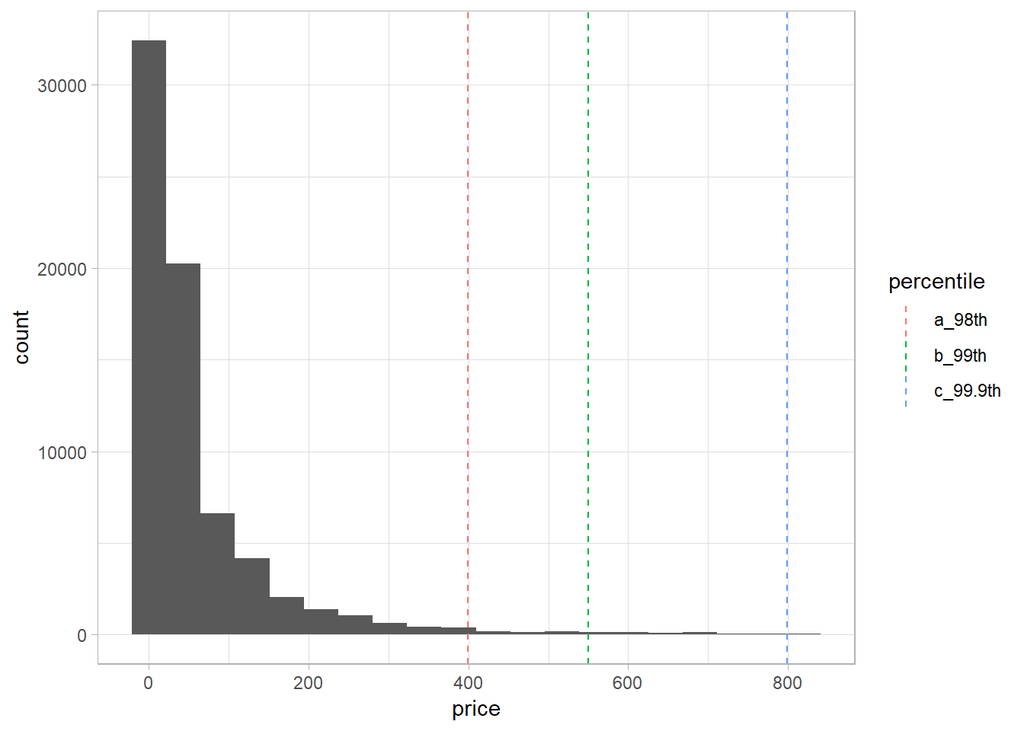

```r
dsfiltered <- filter(dsnocars, price < quantile(dsnocars$price,0.99))
percentile_var=quantile(dsfiltered$price, c(0.98, 0.99, 0.999), na.rm = T)
df_p=data.frame(value=percentile_var, percentile=c("a_98th", "b_99th", "c_99.9th"))
ggplot(dsfiltered, aes(price)) + geom_histogram(bins=20) + geom_vline(data=df_p, aes(xintercept=value,  colour = percentile), show.legend = TRUE, linetype="dashed") + theme_light()
```

```r
summary(dsfiltered$price)
```

```
##    Min. 1st Qu.  Median    Mean 3rd Qu.    Max.
##    1.00    9.00   24.99   61.32   66.90  820.00
```

## 3.2 Podsumowanie danych pod względem kategorii i ich modyfikacja

Aby znaleźć najbardziej istotne główne kategorie produktów zrobiłem wykres łącznej sumy zamówień dla każdej kategorii.

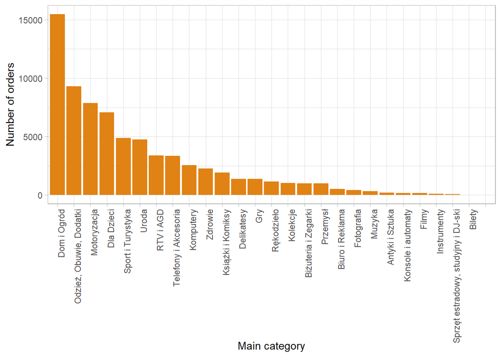

```r
c <- count(ds, ds$main_category)
colnames(c) <- c("Main category","freq")

ggplot(data=c, aes(x=reorder(c$`Main category`, -c$freq), y=c$freq)) + geom_bar(stat = "identity",fill=brewer.pal(n=10, name="PuOr")[3]) + ylab("Number of orders") + xlab("Main category") + theme_light() + theme(axis.text.x = element_text(angle = 90, hjust = 1))
```

Oraz wykres Gross Merchandise Value (GMV).

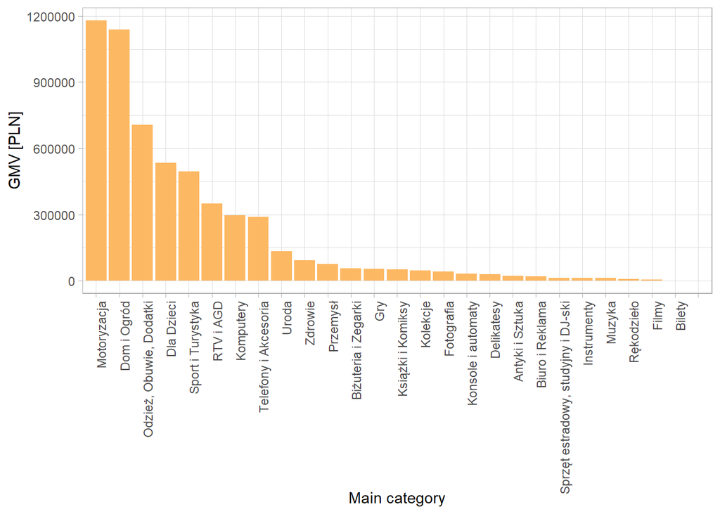

```r
gmv <- aggregate(ds$price, list(ds$main_category), sum)
colnames(gmv) <- c("Main category","GMV")
ggplot(data=gmv, aes(x=reorder(gmv$`Main category`, -gmv$GMV), y=gmv$GMV)) + geom_bar(stat = "identity",fill=brewer.pal(n=9, name="PuOr")[3]) +
  ylab("GMV [PLN]") + xlab("Main category") + theme_light() + theme(axis.text.x = element_text(angle = 90, hjust = 1))
```

Aby znaleźć godziny, w których najczęściej wykonywane są zakupy na allegro, wykonałem wykres ilości zamówień od czasu.

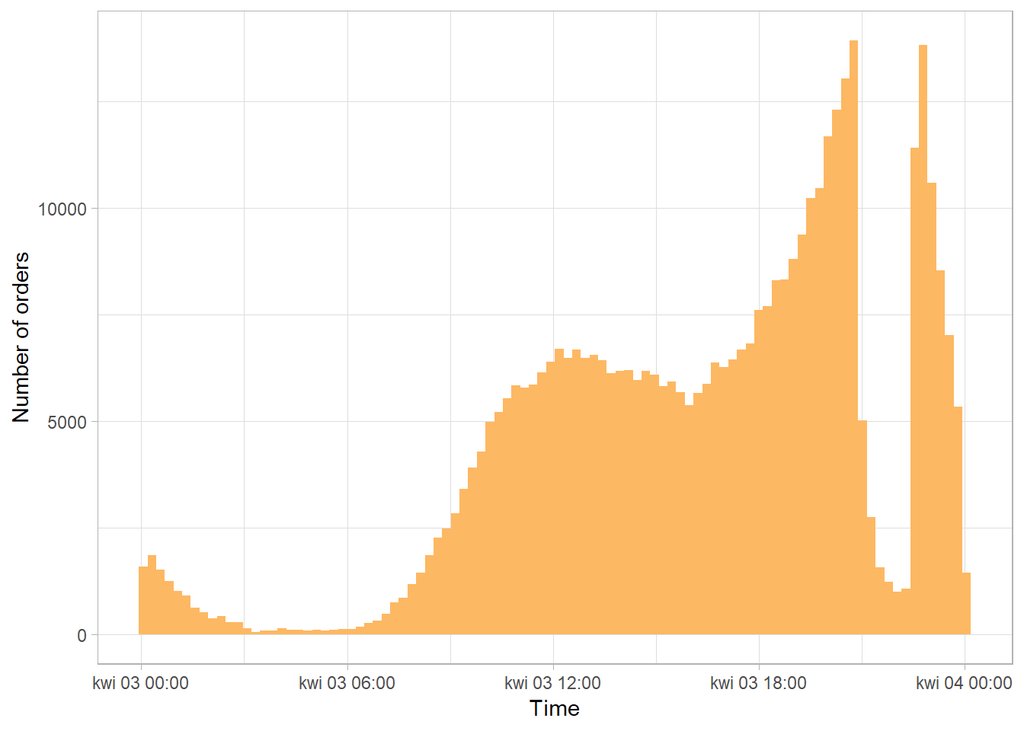

```r
ggplot(dsx, aes(x=date)) +
  geom_histogram(bins = 24*4,fill=brewer.pal(n=8, name="PuOr")[3]) +
  xlab("Time") + ylab("Number of orders") + theme_light()
```

Można zauważyć na nim znaczny spadek w okolicach godziny 22.

# 4 Zależności zmiennych

Do dalszych rozważań ograniczyłem głóWną kategorię do 5 kategorii z największą liczbą zamówień, tzn: “Dom i Ogród”,“Odzież, Obuwie, Dodatki”,“Motoryzacja”,“Dla Dzieci”,“Sport i Turystyka”.

## 4.1 Współczynnik zależności zmiennych

Aby uzyskać więcej informacji wykorzystałem pakiet `minerva` i jego komendę `mine`, za pomocą której wyliczyłem współczynnik zależności zmiennych MIC - Maximal Information Coefficient, który potem przedstawiłem na wykresie za pomocą pakietu `corrplot`.

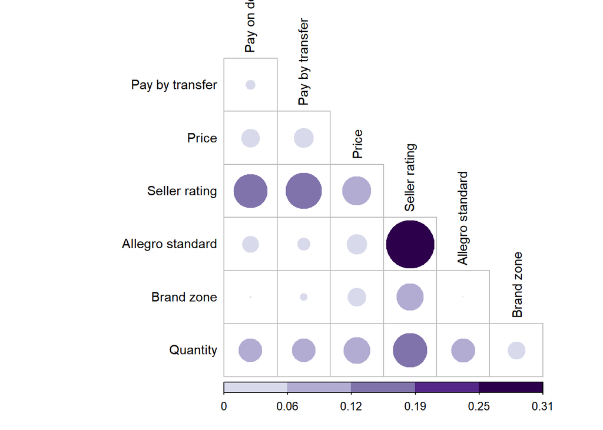

```r
dstop5_4 =
  select(dstop5, pay_option_on_delivery, pay_option_transfer,price, it_seller_rating, it_is_allegro_standard, it_is_brand_zone, it_quantity)
mine_res_hd_2=mine(dstop5_4)
x <- mine_res_hd_2$MIC
colnames(x) <- c("Pay on delivery", "Pay by transfer", "Price", "Seller rating", "Allegro standard", "Brand zone", "Quantity")
rownames(x) <- colnames(x)
corrplot(x,
         method="circle",
         col=brewer.pal(n=10, name="PuOr"),
         type="lower",
         tl.col="black",
         tl.cex = 0.9,
         tl.srt=90,
         diag=FALSE,
         is.corr = F
)
```

## 4.2 Zależność “Pay on delivery”

Sprawdziłem zależność płatności przy odbiorze od kategorii:

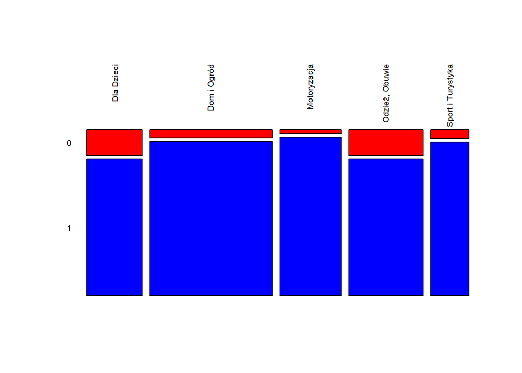

```r
dstop5 <- filter(dsfiltered, main_category%in%c("Dom i Ogród","Odzież, Obuwie, Dodatki","Motoryzacja","Dla Dzieci","Sport i Turystyka"))
dstop5$main_category <- factor(dstop5$main_category)
tab <- table(dstop5$main_category, dstop5$pay_option_on_delivery)
rownames(tab) <- c("Dla Dzieci","Dom i Ogród","Motoryzacja","         Odzież, Obuwie", "a                Sport i Turystyka")
mosaicplot(tab, las=2, main="", color = c("red", "blue"))
```

Następnie po zauważeniu, że zmienna określająca płatność przy odbiorze zależy w dużej mierze od ocen sprzedającego, zrobiłem wykres tej zależności za pomocą funkcji ‘cross_plot’ z pakietu `funModeling`.

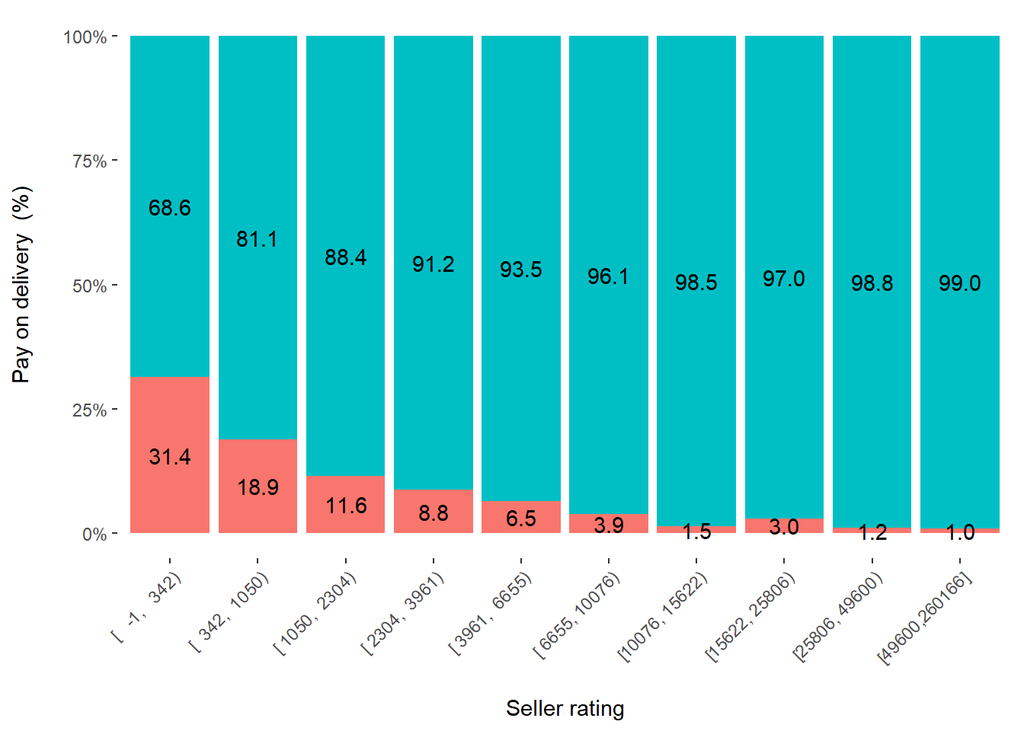

```r
colnames(dstop5)[12] <- "Seller rating"
colnames(dstop5)[5] <- "Pay on delivery"
suppressMessages(cross_plot(dstop5, input = "Seller rating", target = "Pay on delivery", plot_type = "percentual", auto_binning = TRUE))
```

Można zauważyć, że przedstawia on jasno, że im więcej ratingu ma sprzedający, tym częściej przedmioty, które sprzedaje są opłacane przy odbiorze. Może to wynikać z tego, że największy rating mają sklepy internetowe, dla których ta opcja jest najłatwiejsza.

## 4.3 Zależność ilości sprzedanych produktów przez sprzedawców

Aby sprawdzić, od czego zależy sukces danego sprzedawcy na allegro stworzyłem ramkę danych, w której znalazła się zliczona suma sprzedanych przedmiotów przez użytkownika. Następnie ponownie za pomocą funkcji `mine` obliczyłem współczynnik powiązania danych, tym razem liczącą współczynnik korelacji MIC ze zmienną opisującą sumę sprzedanych przedmiotów danego użytkownika. Wyniki zostały przedstawione na poniższym wykresie.

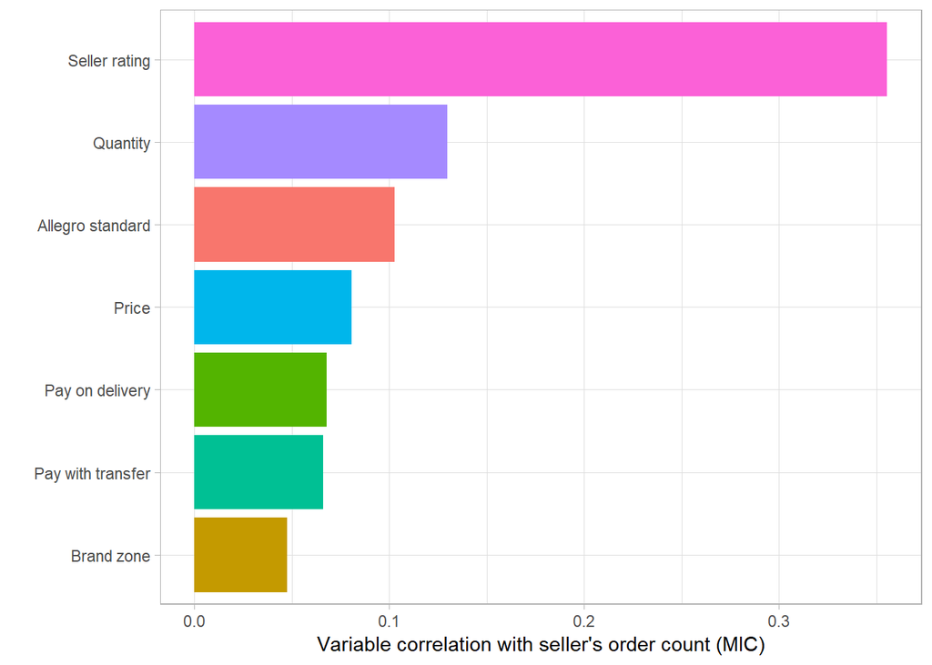

```r
dstop5 <- as.data.frame(dstop5)
dstop5a <- select(dstop5, `Pay on delivery`, pay_option_transfer, seller, price, it_is_allegro_standard, it_quantity, it_is_brand_zone, `Seller rating`)
d <- group_by(dstop5a, seller, add=TRUE) %>% tally()
d <- data.frame(d)
result <- suppressMessages(inner_join(dstop5a, d))
colnames(result) <- c("Pay on delivery", "Pay with transfer", "Seller", "Price", "Allegro standard", "Quantity", "Brand zone", "Seller rating", "Number of sold products")
result <- select(result, -Seller)
target="Number of sold products"
index_target=grep(target, colnames(result))
mic_predictive=mine(result,
                    master = index_target)$MIC

df_predictive =
  data.frame(variable=rownames(mic_predictive),
             mic=mic_predictive[,1],
             stringsAsFactors = F) %>%
  arrange(-mic) %>%
  filter(variable!=target)

ggplot(df_predictive,
       aes(x=reorder(variable, mic),y=mic, fill=variable)
) +
  geom_bar(stat='identity') +
  coord_flip() +
  theme_light() +
  xlab("") +
  ylab("Variable correlation with seller's order count (MIC)") +
  guides(fill=FALSE)
```